# Project - Credit Card Customer Segmentation

##### AllLife Credit Card Customer Segmentation

# Objective:

To identify different segments in the existing customer based on their spending patterns as well as past interaction with the bank.

### Background

AllLife Bank wants to focus on its credit card customer base in the next financial year. They have been advised by their marketing research team, that the penetration in the market can be improved. Based on this input, the Marketing team proposes to run personalised campaigns to target new customers as well as upsell to existing customers. Another insight from the market research was that the customers perceive the support services of the back poorly. Based on this, the Operations team wants to upgrade the service delivery model, to ensure that customers queries are resolved faster. Head of Marketing and Head of Delivery both decide to reach out to the Data Science team for help.

### Key Questions

1. How many different segments of customers are there?
2. How are these segments different from each other?
3. What are your recommendations to the bank on how to better market to and service these customers?

#### Data Description

Data is of various customers of a bank with their credit limit, the total number of credit cards the customer has, and different channels through which customer has contacted the bank for any queries, different channels include visiting the bank, online and through a call.

- Customer key - Identifier for the customer
- Average Credit Limit - Average credit limit across all the credit cards
- Total credit cards - Total number of credit cards
- Total visits bank - Total number of bank visits
- Total visits online - total number of online visits
- Total calls made - Total number of calls made by the customer

## Dataset Information

The data for this project is available in file 'Credit Card Customer Data.xlsx'

## Import Libraries and some necessary modules

```python
#Import the basic modules
import numpy as np
import seaborn as sns
import pandas as pd
import pandas_profiling
import warnings
warnings.filterwarnings('ignore')
%matplotlib inline
import matplotlib.pyplot as plt
```

```python
from sklearn.cluster import KMeans
from sklearn.cluster import AgglomerativeClustering

from sklearn.preprocessing import LabelEncoder

from sklearn.preprocessing import MinMaxScaler
from sklearn.preprocessing import StandardScaler

from sklearn.model_selection import train_test_split

from scipy.cluster.hierarchy import cophenet, dendrogram, linkage
from scipy.cluster.hierarchy import fcluster

from scipy.spatial.distance import pdist  #Pairwise distribution between data points
from sklearn.metrics import silhouette_score
```

## Load Dataset

```python
#load the Excel file into pandas dataframe
df=pd.read_excel('Credit Card Customer Data.xlsx',index_col='Sl_No')
df.head(10)
```

| Sl_No | Customer Key | Avg_Credit_Limit | Total_Credit_Cards | Total_visits_bank | Total_visits_online | Total_calls_made |
| --- | --- | --- | --- | --- | --- | --- |
| 1 | 87073 | 100000 | 2 | 1 | 1 | 0 |
| 2 | 38414 | 50000 | 3 | 0 | 10 | 9 |
| 3 | 17341 | 50000 | 7 | 1 | 3 | 4 |
| 4 | 40496 | 30000 | 5 | 1 | 1 | 4 |
| 5 | 47437 | 100000 | 6 | 0 | 12 | 3 |
| 6 | 58634 | 20000 | 3 | 0 | 1 | 8 |
| 7 | 48370 | 100000 | 5 | 0 | 11 | 2 |
| 8 | 37376 | 15000 | 3 | 0 | 1 | 1 |
| 9 | 82490 | 5000 | 2 | 0 | 2 | 2 |
| 10 | 44770 | 3000 | 4 | 0 | 1 | 7 |

```python
df.shape
```

```
(660, 6)
```

```python
df.dtypes
```

```
Customer Key           int64
Avg_Credit_Limit       int64
Total_Credit_Cards     int64
Total_visits_bank      int64
Total_visits_online    int64
Total_calls_made       int64
dtype: object
```

```python
df.describe().T
#comments on the describe() output observations are given in the initial univariate insights.
```

|  | count | mean | std | min | 25% | 50% | 75% | max |
| --- | --- | --- | --- | --- | --- | --- | --- | --- |
| Customer Key | 660.0 | 55141.443939 | 25627.772200 | 11265.0 | 33825.25 | 53874.5 | 77202.5 | 99843.0 |
| Avg_Credit_Limit | 660.0 | 34574.242424 | 37625.487804 | 3000.0 | 10000.00 | 18000.0 | 48000.0 | 200000.0 |
| Total_Credit_Cards | 660.0 | 4.706061 | 2.167835 | 1.0 | 3.00 | 5.0 | 6.0 | 10.0 |
| Total_visits_bank | 660.0 | 2.403030 | 1.631813 | 0.0 | 1.00 | 2.0 | 4.0 | 5.0 |
| Total_visits_online | 660.0 | 2.606061 | 2.935724 | 0.0 | 1.00 | 2.0 | 4.0 | 15.0 |
| Total_calls_made | 660.0 | 3.583333 | 2.865317 | 0.0 | 1.00 | 3.0 | 5.0 | 10.0 |

```python
df.info()
```

```
<class 'pandas.core.frame.DataFrame'>
Int64Index: 660 entries, 1 to 660
Data columns (total 6 columns):
 #   Column               Non-Null Count  Dtype
---  ------               --------------  -----
 0   Customer Key         660 non-null    int64
 1   Avg_Credit_Limit     660 non-null    int64
 2   Total_Credit_Cards   660 non-null    int64
 3   Total_visits_bank    660 non-null    int64
 4   Total_visits_online  660 non-null    int64
 5   Total_calls_made     660 non-null    int64
dtypes: int64(6)
memory usage: 36.1 KB
```

```python
# Check for missing value
df.isna().sum()
# there were no missing values observed
```

```
Customer Key           0
Avg_Credit_Limit       0
Total_Credit_Cards     0
Total_visits_bank      0
Total_visits_online    0
Total_calls_made       0
dtype: int64
```

```python
# although Na shows no missing value I checked for presence of "?"
# there were none observed in the data
```

```python
df[df['Avg_Credit_Limit']=="?"]
```

|  | Customer Key | Avg_Credit_Limit | Total_Credit_Cards | Total_visits_bank | Total_visits_online | Total_calls_made |
| --- | --- | --- | --- | --- | --- | --- |
| Sl_No |  |  |  |  |  |  |

```python
df[df['Total_Credit_Cards']=="?"]
```

|  | Customer Key | Avg_Credit_Limit | Total_Credit_Cards | Total_visits_bank | Total_visits_online | Total_calls_made |
| --- | --- | --- | --- | --- | --- | --- |
| Sl_No |  |  |  |  |  |  |

```python
df[df['Total_visits_bank']=="?"]
```

|  | Customer Key | Avg_Credit_Limit | Total_Credit_Cards | Total_visits_bank | Total_visits_online | Total_calls_made |
| --- | --- | --- | --- | --- | --- | --- |
| Sl_No |  |  |  |  |  |  |

```python
df[df['Total_visits_online']=="?"]
```

|  | Customer Key | Avg_Credit_Limit | Total_Credit_Cards | Total_visits_bank | Total_visits_online | Total_calls_made |
| --- | --- | --- | --- | --- | --- | --- |
| Sl_No |  |  |  |  |  |  |

```python
df[df['Total_calls_made']=="?"]
```

|  | Customer Key | Avg_Credit_Limit | Total_Credit_Cards | Total_visits_bank | Total_visits_online | Total_calls_made |
| --- | --- | --- | --- | --- | --- | --- |
| Sl_No |  |  |  |  |  |  |

```python
# Check for duplicate rows
dups = df.duplicated()
print('Number of duplicate rows = %d' % (dups.sum()))
df[dups]
```

```
Number of duplicate rows = 0
```

|  | Customer Key | Avg_Credit_Limit | Total_Credit_Cards | Total_visits_bank | Total_visits_online | Total_calls_made |
| --- | --- | --- | --- | --- | --- | --- |
| Sl_No |  |  |  |  |  |  |

```python
# Check for duplicate entries.
duplicate_entries = df.groupby('Customer Key').count()

for k in list(duplicate_entries.loc[duplicate_entries.Total_calls_made >=2].index):
    display(df.loc[df['Customer Key'] == k])

# There are 5 duplicate entries. However after careful review, the decision was to keep these entries
```

| Sl_No | Customer Key | Avg_Credit_Limit | Total_Credit_Cards | Total_visits_bank | Total_visits_online | Total_calls_made |
| --- | --- | --- | --- | --- | --- | --- |
| 49 | 37252 | 6000 | 4 | 0 | 2 | 8 |
| 433 | 37252 | 59000 | 6 | 2 | 1 | 2 |

| Sl_No | Customer Key | Avg_Credit_Limit | Total_Credit_Cards | Total_visits_bank | Total_visits_online | Total_calls_made |
| --- | --- | --- | --- | --- | --- | --- |
| 5 | 47437 | 100000 | 6 | 0 | 12 | 3 |
| 333 | 47437 | 17000 | 7 | 3 | 1 | 0 |

| Sl_No | Customer Key | Avg_Credit_Limit | Total_Credit_Cards | Total_visits_bank | Total_visits_online | Total_calls_made |
| --- | --- | --- | --- | --- | --- | --- |
| 412 | 50706 | 44000 | 4 | 5 | 0 | 2 |
| 542 | 50706 | 60000 | 7 | 5 | 2 | 2 |

| Sl_No | Customer Key | Avg_Credit_Limit | Total_Credit_Cards | Total_visits_bank | Total_visits_online | Total_calls_made |
| --- | --- | --- | --- | --- | --- | --- |
| 392 | 96929 | 13000 | 4 | 5 | 0 | 0 |
| 399 | 96929 | 67000 | 6 | 2 | 2 | 2 |

| Sl_No | Customer Key | Avg_Credit_Limit | Total_Credit_Cards | Total_visits_bank | Total_visits_online | Total_calls_made |
| --- | --- | --- | --- | --- | --- | --- |
| 105 | 97935 | 17000 | 2 | 1 | 2 | 10 |
| 633 | 97935 | 187000 | 7 | 1 | 7 | 0 |

# Steps to Follow:

### 1. Perform univariate analysis on the data to better understand the variables at your disposal and to get an idea about the no of clusters. Perform EDA, create visualizations to explore data. (10 marks)

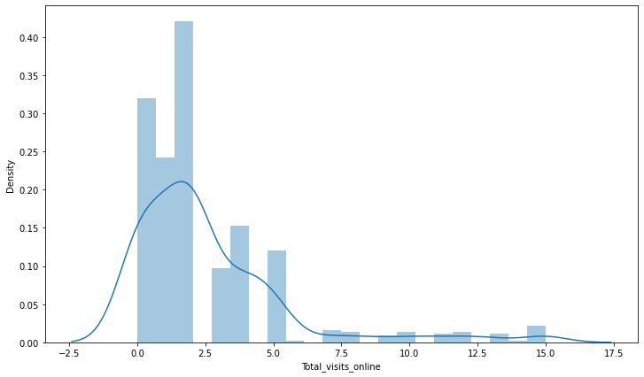

```python
plt.figure(figsize=(12,7))
sns.distplot(df.Total_visits_online);
```

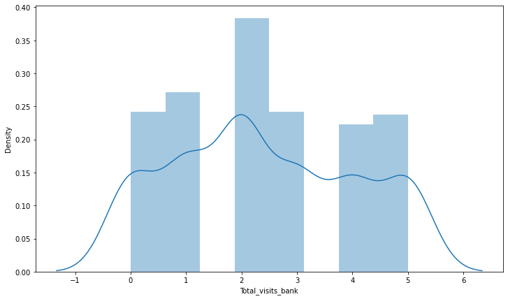

```python
plt.figure(figsize=(12,7))
sns.distplot(df.Total_visits_bank);
```

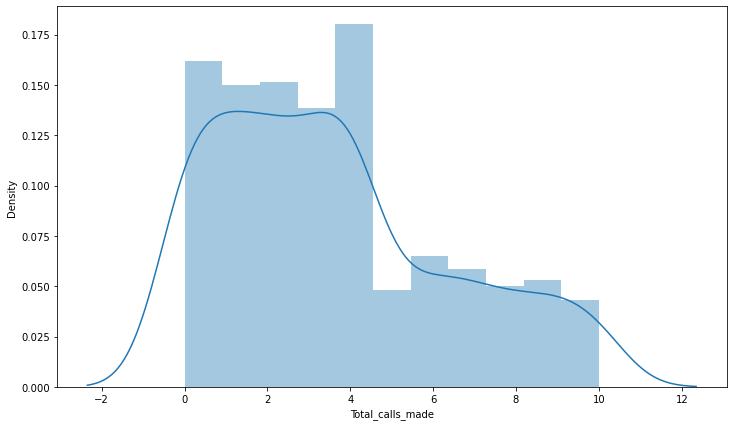

```python
plt.figure(figsize=(12,7))
sns.distplot(df.Total_calls_made);
```

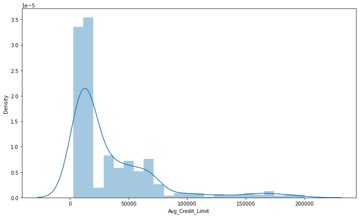

```python
plt.figure(figsize=(12,7))
sns.distplot(df.Avg_Credit_Limit);
```

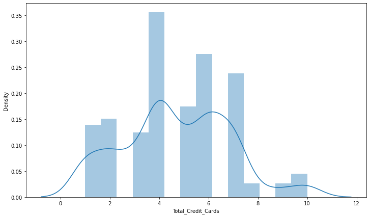

```python
plt.figure(figsize=(12,7))
sns.distplot(df.Total_Credit_Cards);
```